# Project: TMDb Movie Data Analysis

- Data Wrangling
- Exploratory Data Analysis
- Conclusions

```python
import pandas as pd
import numpy as np
import matplotlib.pyplot as plt
import seaborn as sb
import seaborn as sns
%matplotlib inline
```

## Data Wrangling

> **First**: In this section, I will load in the data, then check for cleanliness, and then trim and clean your dataset for analysis. Make sure that I document our steps carefully and justify our cleaning decisions.

### General Properties

```python
# Load dataset
df = pd.read_csv('tmdb-movies.csv')
df.head()
```

|  | id | imdb_id | popularity | budget | revenue | original_title | cast | homepage | director | tagline | ... | overview | runtime | genres | production_companies | release_date | vote_count | vote_average | release_year | budget_adj | revenue_adj |
| --- | --- | --- | --- | --- | --- | --- | --- | --- | --- | --- | --- | --- | --- | --- | --- | --- | --- | --- | --- | --- | --- |
| 0 | 135397 | tt0369610 | 32.985763 | 150000000 | 1513528810 | Jurassic World | Chris Pratt\|Bryce Dallas Howard\|Irrfan Khan\|Vi... | http://www.jurassicworld.com/ | Colin Trevorrow | The park is open. | ... | Twenty-two years after the events of Jurassic ... | 124 | Action\|Adventure\|Science Fiction\|Thriller | Universal Studios\|Amblin Entertainment\|Legenda... | 6/9/15 | 5562 | 6.5 | 2015 | 1.379999e+08 | 1.392446e+09 |
| 1 | 76341 | tt1392190 | 28.419936 | 150000000 | 378436354 | Mad Max: Fury Road | Tom Hardy\|Charlize Theron\|Hugh Keays-Byrne\|Nic... | http://www.madmaxmovie.com/ | George Miller | What a Lovely Day. | ... | An apocalyptic story set in the furthest reach... | 120 | Action\|Adventure\|Science Fiction\|Thriller | Village Roadshow Pictures\|Kennedy Miller Produ... | 5/13/15 | 6185 | 7.1 | 2015 | 1.379999e+08 | 3.481613e+08 |
| 2 | 262500 | tt2908446 | 13.112507 | 110000000 | 295238201 | Insurgent | Shailene Woodley\|Theo James\|Kate Winslet\|Ansel... | http://www.thedivergentseries.movie/#insurgent | Robert Schwentke | One Choice Can Destroy You | ... | Beatrice Prior must confront her inner demons ... | 119 | Adventure\|Science Fiction\|Thriller | Summit Entertainment\|Mandeville Films\|Red Wago... | 3/18/15 | 2480 | 6.3 | 2015 | 1.012000e+08 | 2.716190e+08 |
| 3 | 140607 | tt2488496 | 11.173104 | 200000000 | 2068178225 | Star Wars: The Force Awakens | Harrison Ford\|Mark Hamill\|Carrie Fisher\|Adam D... | http://www.starwars.com/films/star-wars-episod... | J.J. Abrams | Every generation has a story. | ... | Thirty years after defeating the Galactic Empi... | 136 | Action\|Adventure\|Science Fiction\|Fantasy | Lucasfilm\|Truenorth Productions\|Bad Robot | 12/15/15 | 5292 | 7.5 | 2015 | 1.839999e+08 | 1.902723e+09 |
| 4 | 168259 | tt2820852 | 9.335014 | 190000000 | 1506249360 | Furious 7 | Vin Diesel\|Paul Walker\|Jason Statham\|Michelle ... | http://www.furious7.com/ | James Wan | Vengeance Hits Home | ... | Deckard Shaw seeks revenge against Dominic Tor... | 137 | Action\|Crime\|Thriller | Universal Pictures\|Original Film\|Media Rights ... | 4/1/15 | 2947 | 7.3 | 2015 | 1.747999e+08 | 1.385749e+09 |

5 rows × 21 columns

```python
# same thing applies to `.tail()` which returns the last few rows
df.tail(1)
```

|  | id | imdb_id | popularity | budget | revenue | original_title | cast | homepage | director | tagline | ... | overview | runtime | genres | production_companies | release_date | vote_count | vote_average | release_year | budget_adj | revenue_adj |
| --- | --- | --- | --- | --- | --- | --- | --- | --- | --- | --- | --- | --- | --- | --- | --- | --- | --- | --- | --- | --- | --- |
| 10865 | 22293 | tt0060666 | 0.035919 | 19000 | 0 | Manos: The Hands of Fate | Harold P. Warren\|Tom Neyman\|John Reynolds\|Dian... | NaN | Harold P. Warren | It's Shocking! It's Beyond Your Imagination! | ... | A family gets lost on the road and stumbles up... | 74 | Horror | Norm-Iris | 11/15/66 | 15 | 1.5 | 1966 | 127642.279154 | 0.0 |

1 rows × 21 columns

### Data Cleaning (Similarty, Unusfel data And Missing values)

>

> For the first two columns `id` and `imdb_id` seem that to be similar, and second one may not useful I will dispose `imdb_id` column.

> `popularity`, `budget` and `revenue` appeared to be useful columns to give good information for our data but before that, but needing some tweaks like missing values. `release_date` and `release_year` columns to convert datetime object.

> `original_title`, `cast`, `director`, `runtime`, `genres`, `production_companies`, `vote_count`, columns may have very useful information for movies. Another colmuns will be dropping.

```python
# check how many have elements of orihinal title column
df.original_title.nunique()
```

```
10571
```

```python
# analyze and drop Rows/Columns with Null values
df = df.dropna()
```

```python
# display data frame   dimensions
print('Data columns\t\tDatatype')
print('––––––––––––––––––––––––––––––––')
print(df.dtypes)
print('––––––––––––––––––––––––––––––––')
print("Dimensions of the dataframe:\
      ({}) rows and ({}) columns".format(df.shape[0],df.shape[1]))
```

```
Data columns		Datatype
––––––––––––––––––––––––––––––––
id                        int64
imdb_id                  object
popularity              float64
budget                    int64
revenue                   int64
original_title           object
cast                     object
homepage                 object
director                 object
tagline                  object
keywords                 object
overview                 object
runtime                   int64
genres                   object
production_companies     object
release_date             object
vote_count                int64
vote_average            float64
release_year              int64
budget_adj              float64
revenue_adj             float64
dtype: object
––––––––––––––––––––––––––––––––
Dimensions of the dataframe:      (1992) rows and (21) columns
```

```python
# pritn number of duplicates in TMDB movies datasets
print(df.duplicated().sum())
```

```
0
```

```python
# drop duplicates TMDB movies datasets
df.drop_duplicates(inplace=True)
```

```python
# drop columns unusing
df.drop(['imdb_id', 'homepage'], axis=1, inplace=True)


print("After dropping columns:\
      ({}) rows | ({}) columns".format(df.shape[0],df.shape[1]))
```

```
After dropping columns:      (1992) rows | (19) columns
```

```python
# check if there any missing values
print('DataColumns\t  MissingValues')
print('––––––––––––––––––––––––––––––––')
print(df.isna().sum())
print('––––––––––––––––––––––––––––––––')
print("({}) rows and ({}) columns".format(df.shape[0],df.shape[1]))
```

```
DataColumns	  MissingValues
––––––––––––––––––––––––––––––––
id                      0
popularity              0
budget                  0
revenue                 0
original_title          0
cast                    0
director                0
tagline                 0
keywords                0
overview                0
runtime                 0
genres                  0
production_companies    0
release_date            0
vote_count              0
vote_average            0
release_year            0
budget_adj              0
revenue_adj             0
dtype: int64
––––––––––––––––––––––––––––––––
(1992) rows and (19) columns
```

```python
# display how many element which value equal Zero in budget column
df[(df['budget'] == 0)].shape[0]
```

```
546
```

```python
# display how many element which value equal Zero in revenue column
df[(df['revenue'] == 0)].shape[0]
```

```
546
```

```python
# to calculate out the profits of each movie will
# subtract from budget
df['profit'] = df['revenue'] - df['budget']
df.tail()
```

|  | id | popularity | budget | revenue | original_title | cast | director | tagline | keywords | overview | runtime | genres | production_companies | release_date | vote_count | vote_average | release_year | budget_adj | revenue_adj | profit |
| --- | --- | --- | --- | --- | --- | --- | --- | --- | --- | --- | --- | --- | --- | --- | --- | --- | --- | --- | --- | --- |
| 10724 | 668 | 1.778746 | 7000000 | 81974493 | On Her Majesty's Secret Service | George Lazenby\|Diana Rigg\|Telly Savalas\|Gabrie... | Peter R. Hunt | Far up! Far out! Far more! James Bond 007 is b... | london\|suicide\|england\|switzerland\|secret iden... | James Bond tracks archnemesis Ernst Blofeld to... | 142 | Adventure\|Action\|Thriller | Eon Productions\|Metro-Goldwyn-Mayer (MGM)\|Danjaq | 12/12/69 | 258 | 6.4 | 1969 | 4.160985e+07 | 4.872780e+08 | 74974493 |
| 10759 | 948 | 1.198849 | 300000 | 70000000 | Halloween | Donald Pleasence\|Jamie Lee Curtis\|P.J. Soles\|N... | John Carpenter | The Night HE Came Home! | female nudity\|nudity\|mask\|babysitter\|halloween | A psychotic murderer, institutionalized since ... | 91 | Horror\|Thriller | Compass International Pictures\|Falcon Internat... | 10/25/78 | 522 | 7.3 | 1978 | 1.002810e+06 | 2.339890e+08 | 69700000 |
| 10760 | 8469 | 1.157930 | 2700000 | 141000000 | Animal House | John Belushi\|Tim Matheson\|John Vernon\|Verna Bl... | John Landis | It was the Deltas against the rules... the rul... | female nudity\|sex\|nudity\|collage\|fraternity | At a 1962 College, Dean Vernon Wormer is deter... | 109 | Comedy | Universal Pictures\|Oregon Film Factory\|Stage I... | 7/27/78 | 230 | 6.7 | 1978 | 9.025292e+06 | 4.713208e+08 | 138300000 |
| 10817 | 13963 | 0.064029 | 0 | 321952 | The Last Waltz | Robbie Robertson\|Rick Danko\|Levon Helm\|Richard... | Martin Scorsese | It Started as a Concert. It Became a Celebration. | 1970s\|music | Martin Scorsese's rockumentary intertwines foo... | 117 | Documentary\|Music | FM Productions\|Last Waltz Inc. | 5/1/78 | 33 | 8.0 | 1978 | 0.000000e+00 | 1.076189e+06 | 321952 |
| 10819 | 16214 | 0.044675 | 0 | 78000000 | Hooper | Burt Reynolds\|Robert Klein\|Adam West\|Jan-Micha... | Hal Needham | The greatest stuntman alive! | stuntman\|hollywood | Burt Reynolds plays a legendary stunt man know... | 107 | Action\|Comedy | Warner Bros. | 7/28/78 | 13 | 6.0 | 1978 | 0.000000e+00 | 2.607307e+08 | 78000000 |

```python
# spliting each string in the Series by sep and return a frame
# of dummy/indicator variables
# then merge them an take the mean as an index occurs
# in more than one
genres_df = df.genres.str.get_dummies(sep='|')
df = df.merge(genres_df, left_index=True, right_index=True)
```

```python
# Convert 'release_date' column to datetime
df['release_date'] = pd.to_datetime(df['release_date'])
```

```python
# detecting missing values
print(df.isna().sum())
```

```
id                      0
popularity              0
budget                  0
revenue                 0
original_title          0
cast                    0
director                0
tagline                 0
keywords                0
overview                0
runtime                 0
genres                  0
production_companies    0
release_date            0
vote_count              0
vote_average            0
release_year            0
budget_adj              0
revenue_adj             0
profit                  0
Action                  0
Adventure               0
Animation               0
Comedy                  0
Crime                   0
Documentary             0
Drama                   0
Family                  0
Fantasy                 0
Foreign                 0
History                 0
Horror                  0
Music                   0
Mystery                 0
Romance                 0
Science Fiction         0
TV Movie                0
Thriller                0
War                     0
Western                 0
dtype: int64
```

## Exploratory Data Analysis

```python
# this returns useful descriptive statistics for each column of data
df.describe()
```

|  | id | popularity | budget | revenue | runtime | vote_count | vote_average | release_year | budget_adj | revenue_adj | ... | History | Horror | Music | Mystery | Romance | Science Fiction | TV Movie | Thriller | War | Western |
| --- | --- | --- | --- | --- | --- | --- | --- | --- | --- | --- | --- | --- | --- | --- | --- | --- | --- | --- | --- | --- | --- |
| count | 1992.000000 | 1992.000000 | 1.992000e+03 | 1.992000e+03 | 1992.000000 | 1992.000000 | 1992.000000 | 1992.000000 | 1.992000e+03 | 1.992000e+03 | ... | 1992.000000 | 1992.000000 | 1992.000000 | 1992.000000 | 1992.000000 | 1992.000000 | 1992.000000 | 1992.000000 | 1992.000000 | 1992.000000 |
| mean | 71652.152108 | 1.316763 | 3.454924e+07 | 1.152153e+08 | 106.040161 | 643.616968 | 6.178614 | 2007.796687 | 3.627376e+07 | 1.302391e+08 | ... | 0.028112 | 0.137048 | 0.036145 | 0.074297 | 0.146084 | 0.146084 | 0.008032 | 0.288655 | 0.022088 | 0.010040 |
| std | 92355.883915 | 1.873563 | 5.061878e+07 | 2.202887e+08 | 29.234592 | 1092.355998 | 0.881955 | 7.549224 | 5.129783e+07 | 2.564338e+08 | ... | 0.165336 | 0.343985 | 0.186697 | 0.262320 | 0.353279 | 0.353279 | 0.089284 | 0.453251 | 0.147008 | 0.099721 |
| min | 11.000000 | 0.000620 | 0.000000e+00 | 0.000000e+00 | 0.000000 | 10.000000 | 2.100000 | 1961.000000 | 0.000000e+00 | 0.000000e+00 | ... | 0.000000 | 0.000000 | 0.000000 | 0.000000 | 0.000000 | 0.000000 | 0.000000 | 0.000000 | 0.000000 | 0.000000 |
| 25% | 9699.000000 | 0.384079 | 0.000000e+00 | 0.000000e+00 | 92.000000 | 51.000000 | 5.600000 | 2006.000000 | 0.000000e+00 | 0.000000e+00 | ... | 0.000000 | 0.000000 | 0.000000 | 0.000000 | 0.000000 | 0.000000 | 0.000000 | 0.000000 | 0.000000 | 0.000000 |
| 50% | 35112.500000 | 0.774223 | 1.500000e+07 | 2.578782e+07 | 102.000000 | 210.000000 | 6.200000 | 2010.000000 | 1.524601e+07 | 2.806370e+07 | ... | 0.000000 | 0.000000 | 0.000000 | 0.000000 | 0.000000 | 0.000000 | 0.000000 | 0.000000 | 0.000000 | 0.000000 |
| 75% | 83573.000000 | 1.538639 | 4.800000e+07 | 1.278787e+08 | 116.000000 | 688.250000 | 6.800000 | 2012.000000 | 5.064450e+07 | 1.393645e+08 | ... | 0.000000 | 0.000000 | 0.000000 | 0.000000 | 0.000000 | 0.000000 | 0.000000 | 1.000000 | 0.000000 | 0.000000 |
| max | 414419.000000 | 32.985763 | 4.250000e+08 | 2.781506e+09 | 705.000000 | 9767.000000 | 8.300000 | 2015.000000 | 4.250000e+08 | 2.827124e+09 | ... | 1.000000 | 1.000000 | 1.000000 | 1.000000 | 1.000000 | 1.000000 | 1.000000 | 1.000000 | 1.000000 | 1.000000 |

8 rows × 31 columns

```python
# detecting to know number of each column
{df.columns.get_loc(c):c for idx, c in enumerate(df.columns)}
```

```
{0: 'id',
 1: 'popularity',
 2: 'budget',
 3: 'revenue',
 4: 'original_title',
 5: 'cast',
 6: 'director',
 7: 'tagline',
 8: 'keywords',
 9: 'overview',
 10: 'runtime',
 11: 'genres',
 12: 'production_companies',
 13: 'release_date',
 14: 'vote_count',
```

[output cut: 25 more lines]

### Research Question 1 (What are ten movies Vs highest profit for each one?)

```python
# ordering table by budget with only the specific columns
df_budget = df.groupby(['budget', 'original_title'],as_index=False)[
                        'id', 'popularity', 'revenue', 'cast',
                        'director', 'tagline','keywords', 'overview',
                        'runtime', 'genres','production_companies',
                        'release_date','vote_count', 'vote_average',
                        'release_year','budget_adj', 'revenue_adj',
                        'profit', 'Action','Adventure', 'Animation',
                        'Comedy', 'Crime','Documentary', 'Drama',
                        'Family', 'Fantasy','Foreign', 'History',
                        'Horror', 'Music','Mystery', 'Romance',
                        'Science Fiction', 'TV Movie', 'Thriller',
                        'War', 'Western'].sum()
df_budget.tail(20)
```

|  | budget | original_title | id | popularity | revenue | runtime | vote_count | vote_average | release_year | budget_adj | ... | History | Horror | Music | Mystery | Romance | Science Fiction | TV Movie | Thriller | War | Western |
| --- | --- | --- | --- | --- | --- | --- | --- | --- | --- | --- | --- | --- | --- | --- | --- | --- | --- | --- | --- | --- | --- |
| 1972 | 220000000 | The Avengers | 24428 | 7.637767 | 1519557910 | 143 | 8903 | 7.3 | 2012 | 2.089437e+08 | ... | 0 | 0 | 0 | 0 | 0 | 1 | 0 | 0 | 0 | 0 |
| 1973 | 225000000 | Man of Steel | 49521 | 3.972460 | 662845518 | 143 | 4729 | 6.5 | 2013 | 2.106075e+08 | ... | 0 | 0 | 0 | 0 | 0 | 1 | 0 | 0 | 0 | 0 |
| 1974 | 225000000 | Men in Black 3 | 41154 | 2.592896 | 624026776 | 106 | 3142 | 6.1 | 2012 | 2.136925e+08 | ... | 0 | 0 | 0 | 0 | 0 | 1 | 0 | 0 | 0 | 0 |
| 1975 | 237000000 | Avatar | 19995 | 9.432768 | 2781505847 | 162 | 8458 | 7.1 | 2009 | 2.408869e+08 | ... | 0 | 0 | 0 | 0 | 0 | 1 | 0 | 0 | 0 | 0 |
| 1976 | 245000000 | Spectre | 206647 | 6.200282 | 880674609 | 148 | 3254 | 6.2 | 2015 | 2.253999e+08 | ... | 0 | 0 | 0 | 0 | 0 | 0 | 0 | 0 | 0 | 0 |
| 1977 | 250000000 | Harry Potter and the Deathly Hallows: Part 1 | 12444 | 4.840588 | 954305868 | 146 | 3467 | 7.4 | 2010 | 2.500000e+08 | ... | 0 | 0 | 0 | 0 | 0 | 0 | 0 | 0 | 0 | 0 |
| 1978 | 250000000 | Harry Potter and the Half-Blood Prince | 767 | 5.076472 | 933959197 | 153 | 3220 | 7.3 | 2009 | 2.541001e+08 | ... | 0 | 0 | 0 | 0 | 0 | 0 | 0 | 0 | 0 | 0 |
| 1979 | 250000000 | The Dark Knight Rises | 49026 | 6.591277 | 1081041287 | 165 | 6723 | 7.5 | 2012 | 2.374361e+08 | ... | 0 | 0 | 0 | 0 | 0 | 0 | 0 | 1 | 0 | 0 |
| 1980 | 250000000 | The Hobbit: An Unexpected Journey | 49051 | 4.218933 | 1017003568 | 169 | 6417 | 6.9 | 2012 | 2.374361e+08 | ... | 0 | 0 | 0 | 0 | 0 | 0 | 0 | 0 | 0 | 0 |
| 1981 | 250000000 | The Hobbit: The Battle of the Five Armies | 122917 | 10.174599 | 955119788 | 144 | 3110 | 7.1 | 2014 | 2.302728e+08 | ... | 0 | 0 | 0 | 0 | 0 | 0 | 0 | 0 | 0 | 0 |
| 1982 | 250000000 | The Hobbit: The Desolation of Smaug | 57158 | 4.310786 | 958400000 | 161 | 2952 | 7.6 | 2013 | 2.340083e+08 | ... | 0 | 0 | 0 | 0 | 0 | 0 | 0 | 0 | 0 | 0 |
| 1983 | 250000000 | X-Men: Days of Future Past | 127585 | 6.052479 | 746000000 | 131 | 4006 | 7.6 | 2014 | 2.302728e+08 | ... | 0 | 0 | 0 | 0 | 0 | 1 | 0 | 0 | 0 | 0 |
| 1984 | 255000000 | The Lone Ranger | 57201 | 1.214510 | 89289910 | 149 | 1607 | 6.0 | 2013 | 2.386885e+08 | ... | 0 | 0 | 0 | 0 | 0 | 0 | 0 | 0 | 0 | 1 |
| 1985 | 258000000 | Spider-Man 3 | 559 | 2.520912 | 890871626 | 139 | 2083 | 5.8 | 2007 | 2.713305e+08 | ... | 0 | 0 | 0 | 0 | 0 | 0 | 0 | 0 | 0 | 0 |
| 1986 | 260000000 | John Carter | 49529 | 1.588457 | 284139100 | 132 | 1479 | 6.0 | 2012 | 2.469335e+08 | ... | 0 | 0 | 0 | 0 | 0 | 1 | 0 | 0 | 0 | 0 |
| 1987 | 260000000 | Tangled | 38757 | 2.865684 | 591794936 | 100 | 2019 | 7.3 | 2010 | 2.600000e+08 | ... | 0 | 0 | 0 | 0 | 0 | 0 | 0 | 0 | 0 | 0 |
| 1988 | 280000000 | Avengers: Age of Ultron | 99861 | 5.944927 | 1405035767 | 141 | 4304 | 7.4 | 2015 | 2.575999e+08 | ... | 0 | 0 | 0 | 0 | 0 | 1 | 0 | 0 | 0 | 0 |
| 1989 | 300000000 | Pirates of the Caribbean: At World's End | 285 | 4.965391 | 961000000 | 169 | 2626 | 6.8 | 2007 | 3.155006e+08 | ... | 0 | 0 | 0 | 0 | 0 | 0 | 0 | 0 | 0 | 0 |
| 1990 | 380000000 | Pirates of the Caribbean: On Stranger Tides | 1865 | 4.955130 | 1021683000 | 136 | 3180 | 6.3 | 2011 | 3.683713e+08 | ... | 0 | 0 | 0 | 0 | 0 | 0 | 0 | 0 | 0 | 0 |
| 1991 | 425000000 | The Warrior's Way | 46528 | 0.250540 | 11087569 | 100 | 74 | 6.4 | 2010 | 4.250000e+08 | ... | 0 | 0 | 0 | 0 | 0 | 0 | 0 | 1 | 0 | 1 |

20 rows × 32 columns

```python
# arranging by highest value
counts_budget = df_budget.groupby(['budget', 'revenue', 'profit',
                                   'popularity', 'original_title'],
                                  as_index=False)['runtime'].sum().tail(20)
bar_budget = counts_budget.sort_values(by= 'budget', ascending= False)
bar_budget
```

|  | budget | revenue | profit | popularity | original_title | runtime |
| --- | --- | --- | --- | --- | --- | --- |
| 1991 | 425000000 | 11087569 | -413912431 | 0.250540 | The Warrior's Way | 100 |
| 1990 | 380000000 | 1021683000 | 641683000 | 4.955130 | Pirates of the Caribbean: On Stranger Tides | 136 |
| 1989 | 300000000 | 961000000 | 661000000 | 4.965391 | Pirates of the Caribbean: At World's End | 169 |
| 1988 | 280000000 | 1405035767 | 1125035767 | 5.944927 | Avengers: Age of Ultron | 141 |
| 1987 | 260000000 | 591794936 | 331794936 | 2.865684 | Tangled | 100 |
| 1986 | 260000000 | 284139100 | 24139100 | 1.588457 | John Carter | 132 |
| 1985 | 258000000 | 890871626 | 632871626 | 2.520912 | Spider-Man 3 | 139 |
| 1984 | 255000000 | 89289910 | -165710090 | 1.214510 | The Lone Ranger | 149 |
| 1983 | 250000000 | 1081041287 | 831041287 | 6.591277 | The Dark Knight Rises | 165 |
| 1982 | 250000000 | 1017003568 | 767003568 | 4.218933 | The Hobbit: An Unexpected Journey | 169 |
| 1981 | 250000000 | 958400000 | 708400000 | 4.310786 | The Hobbit: The Desolation of Smaug | 161 |
| 1980 | 250000000 | 955119788 | 705119788 | 10.174599 | The Hobbit: The Battle of the Five Armies | 144 |
| 1979 | 250000000 | 954305868 | 704305868 | 4.840588 | Harry Potter and the Deathly Hallows: Part 1 | 146 |
| 1978 | 250000000 | 933959197 | 683959197 | 5.076472 | Harry Potter and the Half-Blood Prince | 153 |
| 1977 | 250000000 | 746000000 | 496000000 | 6.052479 | X-Men: Days of Future Past | 131 |
| 1976 | 245000000 | 880674609 | 635674609 | 6.200282 | Spectre | 148 |
| 1975 | 237000000 | 2781505847 | 2544505847 | 9.432768 | Avatar | 162 |
| 1973 | 225000000 | 624026776 | 399026776 | 2.592896 | Men in Black 3 | 106 |
| 1974 | 225000000 | 662845518 | 437845518 | 3.972460 | Man of Steel | 143 |
| 1972 | 220000000 | 1519557910 | 1299557910 | 7.637767 | The Avengers | 143 |

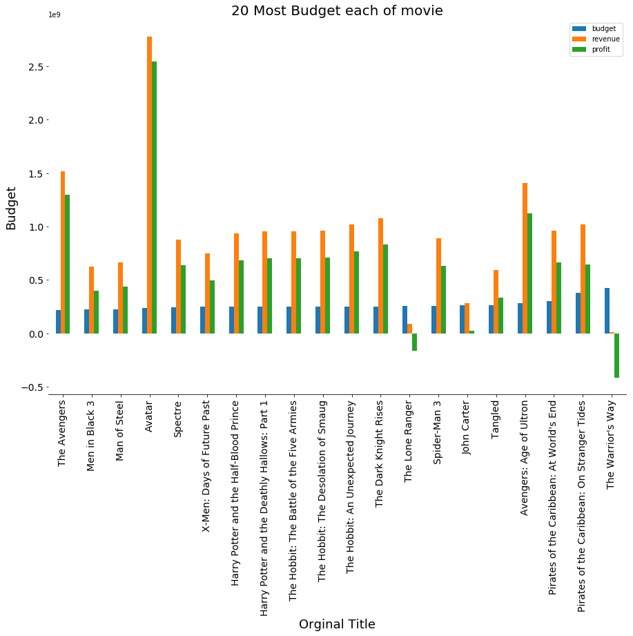

```python
# reating a bar chart for budget and orginal title
bar_budget= pd.DataFrame({'budget': counts_budget['budget'].values,
                          'revenue': counts_budget['revenue'].values,
                          'profit': counts_budget['profit'].values},
                          index= counts_budget['original_title'].values)
# presenting categorical data with rectangular bars with lengths
# proportional to the values that budgets represent
ax= bar_budget.plot.bar(figsize= (15, 10), fontsize= 14, rot=90)

# adding a title to the Figure
ax.set_title('20 Most Budget each of movie', fontsize= 20)

# adding a label to the Axes's x-axis
ax.set_xlabel('Orginal Title', fontsize= 18)

# adding a label to the Axes's y-axis
ax.set_ylabel('Budget', fontsize= 18)

# hiding the top line connecting the Axes's X-axis
# which has boundaried of the data area
ax.spines['top'].set_visible(False)
# hiding the right line connecting  the Axes's Y-axis
# which has boundaried of the data area
ax.spines['right'].set_visible(False)
# hiding the left line connecting the Axes's Y-axis
# which has boundaried of the data area
ax.spines['left'].set_visible(False);
```

```python
# ordering table by profit with only the specific columns
df_profit = df.groupby(['profit', 'original_title'], as_index=False)[
                        'id', 'budget', 'popularity', 'revenue',
                        'cast', 'director', 'tagline','keywords',
                        'overview','runtime', 'genres',
                        'production_companies', 'release_date',
                        'vote_count', 'vote_average', 'release_year',
                        'budget_adj', 'revenue_adj', 'Action',
                        'Adventure', 'Animation', 'Comedy', 'Crime',
                        'Documentary', 'Drama', 'Family', 'Fantasy',
                        'Foreign', 'History', 'Horror', 'Music',
                        'Mystery', 'Romance', 'Science Fiction',
                        'TV Movie', 'Thriller', 'War', 'Western'].sum()
df_profit.tail()
```

|  | profit | original_title | id | budget | popularity | revenue | runtime | vote_count | vote_average | release_year | ... | History | Horror | Music | Mystery | Romance | Science Fiction | TV Movie | Thriller | War | Western |
| --- | --- | --- | --- | --- | --- | --- | --- | --- | --- | --- | --- | --- | --- | --- | --- | --- | --- | --- | --- | --- | --- |
| 1987 | 1316249360 | Furious 7 | 168259 | 190000000 | 9.335014 | 1506249360 | 137 | 2947 | 7.3 | 2015 | ... | 0 | 0 | 0 | 0 | 0 | 0 | 0 | 1 | 0 | 0 |
| 1988 | 1363528810 | Jurassic World | 135397 | 150000000 | 32.985763 | 1513528810 | 124 | 5562 | 6.5 | 2015 | ... | 0 | 0 | 0 | 0 | 0 | 1 | 0 | 1 | 0 | 0 |
| 1989 | 1645034188 | Titanic | 597 | 200000000 | 4.355219 | 1845034188 | 194 | 4654 | 7.3 | 1997 | ... | 0 | 0 | 0 | 0 | 1 | 0 | 0 | 1 | 0 | 0 |
| 1990 | 1868178225 | Star Wars: The Force Awakens | 140607 | 200000000 | 11.173104 | 2068178225 | 136 | 5292 | 7.5 | 2015 | ... | 0 | 0 | 0 | 0 | 0 | 1 | 0 | 0 | 0 | 0 |
| 1991 | 2544505847 | Avatar | 19995 | 237000000 | 9.432768 | 2781505847 | 162 | 8458 | 7.1 | 2009 | ... | 0 | 0 | 0 | 0 | 0 | 1 | 0 | 0 | 0 | 0 |

5 rows × 32 columns

```python
# arranging by highest value
counts_profit = df_profit.groupby(['profit', 'budget', 'popularity',
                                   'original_title'],
                                    as_index=False)['runtime'].sum().tail(10)
bar_profit = counts_profit.sort_values(by='profit', ascending = False)
bar_profit.head(10)
```

|  | profit | budget | popularity | original_title | runtime |
| --- | --- | --- | --- | --- | --- |
| 1991 | 2544505847 | 237000000 | 9.432768 | Avatar | 162 |
| 1990 | 1868178225 | 200000000 | 11.173104 | Star Wars: The Force Awakens | 136 |
| 1989 | 1645034188 | 200000000 | 4.355219 | Titanic | 194 |
| 1988 | 1363528810 | 150000000 | 32.985763 | Jurassic World | 124 |
| 1987 | 1316249360 | 190000000 | 9.335014 | Furious 7 | 137 |
| 1986 | 1299557910 | 220000000 | 7.637767 | The Avengers | 143 |
| 1985 | 1202817822 | 125000000 | 5.711315 | Harry Potter and the Deathly Hallows: Part 2 | 130 |
| 1984 | 1125035767 | 280000000 | 5.944927 | Avengers: Age of Ultron | 141 |
| 1983 | 1124219009 | 150000000 | 6.112766 | Frozen | 102 |
| 1982 | 1082730962 | 74000000 | 7.404165 | Minions | 91 |

```python
# arranging by highest value
counts_budget_profit = counts_profit.groupby(['budget', 'profit',
                                              'popularity', 'original_title'],
                                               as_index=False)['runtime'].sum().tail(10)
bar_budget_profit = counts_budget_profit.sort_values(by='budget', ascending = False)
bar_budget_profit.head(10)
```

|  | budget | profit | popularity | original_title | runtime |
| --- | --- | --- | --- | --- | --- |
| 9 | 280000000 | 1125035767 | 5.944927 | Avengers: Age of Ultron | 141 |
| 8 | 237000000 | 2544505847 | 9.432768 | Avatar | 162 |
| 7 | 220000000 | 1299557910 | 7.637767 | The Avengers | 143 |
| 5 | 200000000 | 1645034188 | 4.355219 | Titanic | 194 |
| 6 | 200000000 | 1868178225 | 11.173104 | Star Wars: The Force Awakens | 136 |
| 4 | 190000000 | 1316249360 | 9.335014 | Furious 7 | 137 |
| 2 | 150000000 | 1124219009 | 6.112766 | Frozen | 102 |
| 3 | 150000000 | 1363528810 | 32.985763 | Jurassic World | 124 |
| 1 | 125000000 | 1202817822 | 5.711315 | Harry Potter and the Deathly Hallows: Part 2 | 130 |
| 0 | 74000000 | 1082730962 | 7.404165 | Minions | 91 |

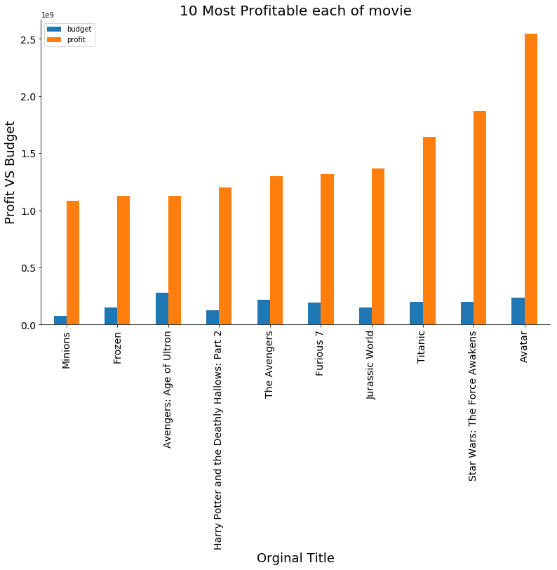

```python
# reating a bar chart for profit and budget for orginal title
bar_profit = pd.DataFrame({'budget' : counts_profit['budget'].values,
                           'profit' : counts_profit['profit'].values},
                            index = counts_profit['original_title'].values)

# presenting categorical data with rectangular bars with lengths
# proportional to the values that budgets represent
ax = bar_profit.plot.bar(figsize= (13,8), fontsize= 14, rot= 90,)

# adding a title to the Figure
ax.set_title('10 Most Profitable each of movie', fontsize= 20)

# adding a label to the Axes's X-axis
ax.set_ylabel('Profit VS Budget',fontsize= 18)

# adding a label to the Axes's y-axis
ax.set_xlabel('Orginal Title', fontsize= 18);

# hiding the top line connecting the Axes's X-axis
# which has boundaried of the data area
ax.spines['top'].set_visible(False)

# hiding the right line connecting the Axes's Y-axis
# which has boundaried of the data area
ax.spines['right'].set_visible(False)

# hiding the left line connecting the Axes's Y-axis
# which has boundaried of the data area
ax.spines['left'].set_visible(True);
```

> We note `Avatar` movie is top one of profit where is more than billion and half.

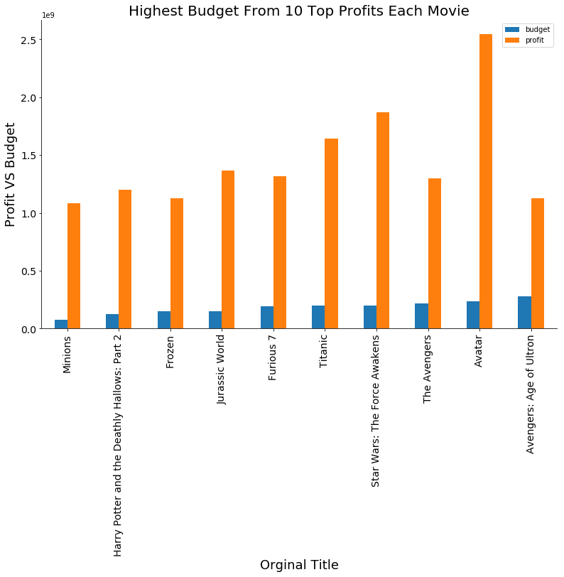

```python
# reating a bar chart for highest budget from 10 top profits each movie
bar_budget_profit = pd.DataFrame({'budget' : counts_budget_profit['budget'].values,
                                  'profit' : counts_budget_profit['profit'].values},
                                   index = counts_budget_profit['original_title'].values)

# presenting categorical data with rectangular bars with lengths
# proportional to the values that that budgets represent
ax = bar_budget_profit.plot.bar(figsize= (13,8), fontsize= 14, rot= 90,)

# adding a title to the Figure
ax.set_title('Highest Budget From 10 Top Profits Each Movie', fontsize= 20)

# adding a label to the Axes's X-axis
ax.set_ylabel('Profit VS Budget',fontsize= 18)

# adding a label to the Axes's Y-axis
ax.set_xlabel('Orginal Title', fontsize= 18);

# hiding the top line connecting the Axes's X-axis
# which has boundaried of the data area
ax.spines['top'].set_visible(False)

# hiding the right line connecting the Axes's Y-axis
# which has boundaried of the data area
ax.spines['right'].set_visible(False)

# hiding the left line connecting the Axes's Y-axis
# which has boundaried of the data area
ax.spines['left'].set_visible(True);
```

> High budget that not mean high profit. Because, when we at look bar chart the `Avengers: Age of Ultron` movie has highest budget but the top profit is `Avatar` movie. Therefore, there is not relationship between them.

```python
# ordering table by revenue with only the specific columns
df_revenue = df.groupby(['revenue', 'original_title'],
                        as_index=False)[
                         'id', 'popularity', 'budget', 'cast',
                         'director', 'tagline', 'keywords', 'overview',
                         'runtime', 'genres', 'production_companies',
                         'release_date', 'vote_count', 'vote_average',
                         'release_year', 'budget_adj', 'revenue_adj',
                         'profit', 'Action', 'Adventure', 'Animation',
                         'Comedy', 'Crime', 'Documentary', 'Drama',
                         'Family', 'Fantasy', 'Foreign', 'History',
                         'Horror', 'Music', 'Mystery', 'Romance',
                         'Science Fiction', 'TV Movie', 'Thriller',
                         'War', 'Western'].sum()
df_revenue.tail(20)
```

|  | revenue | original_title | id | popularity | budget | runtime | vote_count | vote_average | release_year | budget_adj | ... | History | Horror | Music | Mystery | Romance | Science Fiction | TV Movie | Thriller | War | Western |
| --- | --- | --- | --- | --- | --- | --- | --- | --- | --- | --- | --- | --- | --- | --- | --- | --- | --- | --- | --- | --- | --- |
| 1970 | 1017003568 | The Hobbit: An Unexpected Journey | 49051 | 4.218933 | 250000000 | 169 | 6417 | 6.9 | 2012 | 2.374361e+08 | ... | 0 | 0 | 0 | 0 | 0 | 0 | 0 | 0 | 0 | 0 |
| 1971 | 1021683000 | Pirates of the Caribbean: On Stranger Tides | 1865 | 4.955130 | 380000000 | 136 | 3180 | 6.3 | 2011 | 3.683713e+08 | ... | 0 | 0 | 0 | 0 | 0 | 0 | 0 | 0 | 0 | 0 |
| 1972 | 1025467110 | Alice in Wonderland | 12155 | 5.572950 | 200000000 | 108 | 2853 | 6.3 | 2010 | 2.000000e+08 | ... | 0 | 0 | 0 | 0 | 0 | 0 | 0 | 0 | 0 | 0 |
| 1973 | 1063171911 | Toy Story 3 | 10193 | 2.711136 | 200000000 | 103 | 2924 | 7.5 | 2010 | 2.000000e+08 | ... | 0 | 0 | 0 | 0 | 0 | 0 | 0 | 0 | 0 | 0 |
| 1974 | 1065659812 | Pirates of the Caribbean: Dead Man's Chest | 58 | 4.205992 | 200000000 | 151 | 3181 | 6.8 | 2006 | 2.163338e+08 | ... | 0 | 0 | 0 | 0 | 0 | 0 | 0 | 0 | 0 | 0 |
| 1975 | 1081041287 | The Dark Knight Rises | 49026 | 6.591277 | 250000000 | 165 | 6723 | 7.5 | 2012 | 2.374361e+08 | ... | 0 | 0 | 0 | 0 | 0 | 0 | 0 | 1 | 0 | 0 |
| 1976 | 1108561013 | Skyfall | 37724 | 5.603587 | 200000000 | 143 | 6137 | 6.8 | 2012 | 1.899489e+08 | ... | 0 | 0 | 0 | 0 | 0 | 0 | 0 | 1 | 0 | 0 |
| 1977 | 1118888979 | The Lord of the Rings: The Return of the King | 122 | 7.122455 | 94000000 | 201 | 5636 | 7.9 | 2003 | 1.114231e+08 | ... | 0 | 0 | 0 | 0 | 0 | 0 | 0 | 0 | 0 | 0 |
| 1978 | 1123746996 | Transformers: Dark of the Moon | 38356 | 0.760503 | 195000000 | 154 | 2456 | 6.1 | 2011 | 1.890326e+08 | ... | 0 | 0 | 0 | 0 | 0 | 1 | 0 | 0 | 0 | 0 |
| 1979 | 1156730962 | Minions | 211672 | 7.404165 | 74000000 | 91 | 2893 | 6.5 | 2015 | 6.807997e+07 | ... | 0 | 0 | 0 | 0 | 0 | 0 | 0 | 0 | 0 | 0 |
| 1980 | 1215439994 | Iron Man 3 | 68721 | 4.946136 | 200000000 | 130 | 6882 | 6.9 | 2013 | 1.872067e+08 | ... | 0 | 0 | 0 | 0 | 0 | 1 | 0 | 0 | 0 | 0 |
| 1981 | 1274219009 | Frozen | 109445 | 6.112766 | 150000000 | 102 | 3369 | 7.5 | 2013 | 1.404050e+08 | ... | 0 | 0 | 0 | 0 | 0 | 0 | 0 | 0 | 0 | 0 |
| 1982 | 1327817822 | Harry Potter and the Deathly Hallows: Part 2 | 12445 | 5.711315 | 125000000 | 130 | 3750 | 7.7 | 2011 | 1.211748e+08 | ... | 0 | 0 | 0 | 0 | 0 | 0 | 0 | 0 | 0 | 0 |
| 1983 | 1405035767 | Avengers: Age of Ultron | 99861 | 5.944927 | 280000000 | 141 | 4304 | 7.4 | 2015 | 2.575999e+08 | ... | 0 | 0 | 0 | 0 | 0 | 1 | 0 | 0 | 0 | 0 |
| 1984 | 1506249360 | Furious 7 | 168259 | 9.335014 | 190000000 | 137 | 2947 | 7.3 | 2015 | 1.747999e+08 | ... | 0 | 0 | 0 | 0 | 0 | 0 | 0 | 1 | 0 | 0 |
| 1985 | 1513528810 | Jurassic World | 135397 | 32.985763 | 150000000 | 124 | 5562 | 6.5 | 2015 | 1.379999e+08 | ... | 0 | 0 | 0 | 0 | 0 | 1 | 0 | 1 | 0 | 0 |
| 1986 | 1519557910 | The Avengers | 24428 | 7.637767 | 220000000 | 143 | 8903 | 7.3 | 2012 | 2.089437e+08 | ... | 0 | 0 | 0 | 0 | 0 | 1 | 0 | 0 | 0 | 0 |
| 1987 | 1845034188 | Titanic | 597 | 4.355219 | 200000000 | 194 | 4654 | 7.3 | 1997 | 2.716921e+08 | ... | 0 | 0 | 0 | 0 | 1 | 0 | 0 | 1 | 0 | 0 |
| 1988 | 2068178225 | Star Wars: The Force Awakens | 140607 | 11.173104 | 200000000 | 136 | 5292 | 7.5 | 2015 | 1.839999e+08 | ... | 0 | 0 | 0 | 0 | 0 | 1 | 0 | 0 | 0 | 0 |
| 1989 | 2781505847 | Avatar | 19995 | 9.432768 | 237000000 | 162 | 8458 | 7.1 | 2009 | 2.408869e+08 | ... | 0 | 0 | 0 | 0 | 0 | 1 | 0 | 0 | 0 | 0 |

20 rows × 32 columns

```python
# arranging by highest value
counts_revenue = df_revenue.groupby(['revenue', 'budget', 'profit',
                                     'popularity', 'original_title'],
                                      as_index=False)['runtime'].sum().tail(20)
bar_revenue = counts_revenue.sort_values(by= 'revenue', ascending= False)
bar_revenue
```

|  | revenue | budget | profit | popularity | original_title | runtime |
| --- | --- | --- | --- | --- | --- | --- |
| 1989 | 2781505847 | 237000000 | 2544505847 | 9.432768 | Avatar | 162 |
| 1988 | 2068178225 | 200000000 | 1868178225 | 11.173104 | Star Wars: The Force Awakens | 136 |
| 1987 | 1845034188 | 200000000 | 1645034188 | 4.355219 | Titanic | 194 |
| 1986 | 1519557910 | 220000000 | 1299557910 | 7.637767 | The Avengers | 143 |
| 1985 | 1513528810 | 150000000 | 1363528810 | 32.985763 | Jurassic World | 124 |
| 1984 | 1506249360 | 190000000 | 1316249360 | 9.335014 | Furious 7 | 137 |
| 1983 | 1405035767 | 280000000 | 1125035767 | 5.944927 | Avengers: Age of Ultron | 141 |
| 1982 | 1327817822 | 125000000 | 1202817822 | 5.711315 | Harry Potter and the Deathly Hallows: Part 2 | 130 |
| 1981 | 1274219009 | 150000000 | 1124219009 | 6.112766 | Frozen | 102 |
| 1980 | 1215439994 | 200000000 | 1015439994 | 4.946136 | Iron Man 3 | 130 |
| 1979 | 1156730962 | 74000000 | 1082730962 | 7.404165 | Minions | 91 |
| 1978 | 1123746996 | 195000000 | 928746996 | 0.760503 | Transformers: Dark of the Moon | 154 |
| 1977 | 1118888979 | 94000000 | 1024888979 | 7.122455 | The Lord of the Rings: The Return of the King | 201 |
| 1976 | 1108561013 | 200000000 | 908561013 | 5.603587 | Skyfall | 143 |
| 1975 | 1081041287 | 250000000 | 831041287 | 6.591277 | The Dark Knight Rises | 165 |
| 1974 | 1065659812 | 200000000 | 865659812 | 4.205992 | Pirates of the Caribbean: Dead Man's Chest | 151 |
| 1973 | 1063171911 | 200000000 | 863171911 | 2.711136 | Toy Story 3 | 103 |
| 1972 | 1025467110 | 200000000 | 825467110 | 5.572950 | Alice in Wonderland | 108 |
| 1971 | 1021683000 | 380000000 | 641683000 | 4.955130 | Pirates of the Caribbean: On Stranger Tides | 136 |
| 1970 | 1017003568 | 250000000 | 767003568 | 4.218933 | The Hobbit: An Unexpected Journey | 169 |

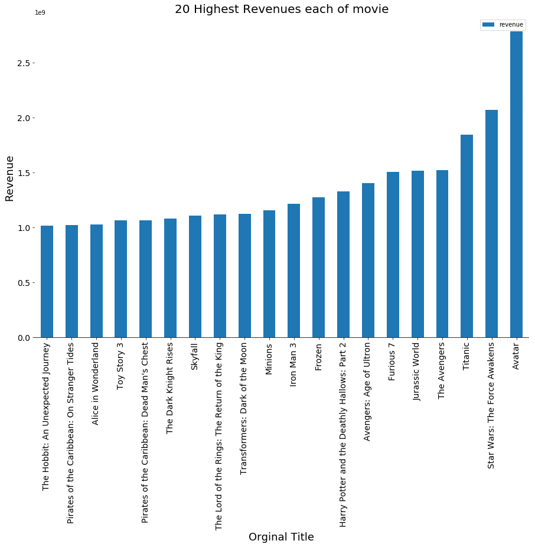

```python
# reating a bar chart for revenue and orginal title
bar_revenue= pd.DataFrame({'revenue': counts_revenue['revenue'].values},
                           #'profit': counts_revenue['profit'].values,
                           #'budget': counts_revenue['budget'].values},
                            index= counts_revenue['original_title'].values)
# presenting categorical data with rectangular bars with lengths
# proportional to the values that budgets represent
ax= bar_revenue.plot.bar(figsize= (15, 10), fontsize= 14, rot=90)

# adding a title to the Figure
ax.set_title('20 Highest Revenues each of movie', fontsize= 20)

# adding a label to the Axes's x-axis
ax.set_xlabel('Orginal Title', fontsize= 18)

# adding a label to the Axes's y-axis
ax.set_ylabel('Revenue', fontsize= 18)

# hiding the top line connecting the Axes's X-axis
# which has boundaried of the data area
ax.spines['top'].set_visible(False)
# hiding the right line connecting  the Axes's Y-axis
# which has boundaried of the data area
ax.spines['right'].set_visible(False)
# hiding the left line connecting the Axes's Y-axis
# which has boundaried of the data area
ax.spines['left'].set_visible(False);
```

```python
# display how many element which value equal one in action column
df_revenue[(df_revenue['Action']== 1)].shape[0]

# display how many element which value equal one in adventure column
df_revenue[(df_revenue['Adventure']== 1)].shape[0]

# display how many element which value equal one in animation column
df_revenue[(df_revenue['Animation']== 1)].shape[0]

# display how many element which value equal one in comedy column
df_revenue[(df_revenue['Comedy']== 1)].shape[0]

# display how many element which value equal One in Crime column
df_revenue[(df_revenue['Crime']== 1)].shape[0]

# display how many element which value equal one in Documentary column
df_revenue[(df_revenue['Documentary']== 1)].shape[0]

# display how many element which value equal one in Drama column
df_revenue[(df_revenue['Drama']== 1)].shape[0]

# display how many element which value equal one in Family column
df_revenue[(df_revenue['Family']== 1)].shape[0]

# display how many element which value equal one in Fantasy column
df_revenue[(df_revenue['Fantasy']== 1)].shape[0]

# display how many element which value equal one in Foreign column
df_revenue[(df_revenue['Foreign']== 1)].shape[0]

# display how many element which value equal one in History column
df_revenue[(df_revenue['History']== 1)].shape[0]

# display how many element which value equal one in Horror column
df_revenue[(df_revenue['Horror']== 1)].shape[0]

# display how many element which value equal one in Music column
df_revenue[(df_revenue['Music']== 1)].shape[0]

# display how many element which value equal one in Mystery column
df_revenue[(df_revenue['Mystery']== 1)].shape[0]

# display how many element which value equal one in Romance column
df_revenue[(df_revenue['Romance']== 1)].shape[0]

# display how many element which value equal one in Science Fiction column
df_revenue[(df_revenue['Science Fiction']== 1)].shape[0]

# display how many element which value equal one in TV Movie column
df_revenue[(df_revenue['TV Movie']== 1)].shape[0]

# display how many element which value equal one in Thriller column
df_revenue[(df_revenue['Thriller']== 1)].shape[0]

# display how many element which value equal one in War column
df_revenue[(df_revenue['War']== 1)].shape[0]

# display how many element which value equal one in Western column
df_revenue[(df_revenue['Western']== 1)].shape[0]
```

```
20
```

```python
data_heights= [530, 361, 170,
       640, 262, 93, 838,
       233, 202, 6, 56,
       273, 72, 148, 291,
       291, 16 , 575, 44, 20]

data_names= ['Action', 'Adventure', 'Animation', 'Comedy', 'Crime', 'Documentary', 'Drama',
        'Family', 'Fantasy', 'Foreign', 'History', 'Horror', 'Music', 'Mystery', 'Romance',
        'Science Fiction', 'TV Movie', 'Thriller', 'War', 'Western']
```

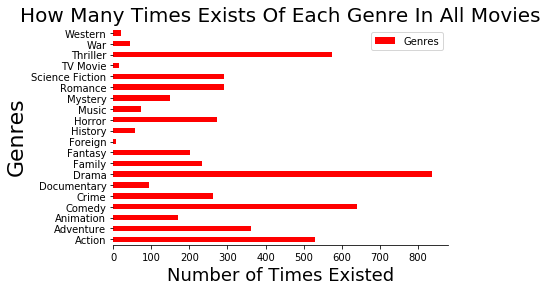

```python
bar_genres= pd.DataFrame({'Genres': data_heights},
                           index= data_names)

#bar_genres.get_map('Set2','qualitative',3,reverse=True)
colors = ['red', 'green', 'blue']
#data.plot('name','value',color=colors,kind='bar')
ax = bar_genres.plot(kind='barh', color= colors)
# adding a title to the Figure
ax.set_title('How Many Times Exists Of Each Genre In All Movies', fontsize= 20)

# adding a label to the Axes's X-axis
ax.set_ylabel('Genres',fontsize= 22)

# adding a label to the Axes's Y-axis
ax.set_xlabel('Number of Times Existed', fontsize= 18);

# hiding the top line connecting the Axes's X-axis
# which has boundaried of the data area
ax.spines['top'].set_visible(False)

# hiding the right line connecting the Axes's Y-axis
# which has boundaried of the data area
ax.spines['right'].set_visible(False)

# hiding the left line connecting the Axes's Y-axis
# which has boundaried of the data area
ax.spines['left'].set_visible(False);
```

```python
# ordering table by revenue with only the specific columns
df_runtime = df.groupby(['runtime', 'original_title'],
                          as_index=False)['id', 'popularity', 'budget',
                                          'cast', 'director', 'tagline',
                                          'keywords', 'overview','revenue', 'genres',
                                          'production_companies', 'release_date',
                                          'vote_count', 'vote_average', 'release_year',
                                          'budget_adj', 'revenue_adj', 'profit', 'Action',
                                          'Adventure', 'Animation', 'Comedy', 'Crime',
                                          'Documentary', 'Drama', 'Family', 'Fantasy',
                                          'Foreign', 'History', 'Horror', 'Music',
                                          'Mystery', 'Romance', 'Science Fiction',
                                          'TV Movie', 'Thriller', 'War', 'Western'].sum()
df_runtime.tail(10)
```

|  | runtime | original_title | id | popularity | budget | revenue | vote_count | vote_average | release_year | budget_adj | ... | History | Horror | Music | Mystery | Romance | Science Fiction | TV Movie | Thriller | War | Western |
| --- | --- | --- | --- | --- | --- | --- | --- | --- | --- | --- | --- | --- | --- | --- | --- | --- | --- | --- | --- | --- | --- |
| 1982 | 195 | Schindler's List | 424 | 2.377288 | 22000000 | 321265768 | 2632 | 8.1 | 1993 | 3.320834e+07 | ... | 1 | 0 | 0 | 0 | 0 | 0 | 0 | 0 | 1 | 0 |
| 1983 | 201 | The Lord of the Rings: The Return of the King | 122 | 7.122455 | 94000000 | 1118888979 | 5636 | 7.9 | 2003 | 1.114231e+08 | ... | 0 | 0 | 0 | 0 | 0 | 0 | 0 | 0 | 0 | 0 |
| 1984 | 201 | Zeitgeist: Moving Forward | 54293 | 0.252508 | 0 | 0 | 39 | 7.2 | 2011 | 0.000000e+00 | ... | 0 | 0 | 0 | 0 | 0 | 0 | 0 | 0 | 0 | 0 |
| 1985 | 247 | Kill Bill: The Whole Bloody Affair | 414419 | 0.146477 | 30000000 | 0 | 28 | 8.1 | 2011 | 2.908194e+07 | ... | 0 | 0 | 0 | 0 | 0 | 0 | 0 | 0 | 0 | 0 |
| 1986 | 285 | Klondike | 242754 | 0.093377 | 0 | 0 | 17 | 6.7 | 2014 | 0.000000e+00 | ... | 1 | 0 | 0 | 0 | 0 | 0 | 0 | 0 | 0 | 0 |
| 1987 | 292 | Frank Herbert's Dune | 876 | 0.381729 | 20000000 | 0 | 67 | 6.5 | 2000 | 2.532584e+07 | ... | 0 | 0 | 0 | 0 | 0 | 1 | 0 | 0 | 0 | 0 |
| 1988 | 336 | Mildred Pierce | 202241 | 0.044221 | 20000000 | 0 | 21 | 6.6 | 2011 | 1.938796e+07 | ... | 0 | 0 | 0 | 0 | 0 | 0 | 0 | 0 | 0 | 0 |
| 1989 | 500 | Life | 220903 | 0.102223 | 0 | 0 | 24 | 7.0 | 2009 | 0.000000e+00 | ... | 0 | 0 | 0 | 0 | 0 | 0 | 0 | 0 | 0 | 0 |
| 1990 | 540 | The Pacific | 189197 | 0.757082 | 120000000 | 0 | 183 | 7.8 | 2010 | 1.200000e+08 | ... | 1 | 0 | 0 | 0 | 0 | 0 | 0 | 0 | 1 | 0 |
| 1991 | 705 | Band of Brothers | 331214 | 0.537593 | 0 | 125000000 | 313 | 8.0 | 2001 | 0.000000e+00 | ... | 0 | 0 | 0 | 0 | 0 | 0 | 0 | 0 | 1 | 0 |

10 rows × 32 columns

```python
# arranging by highest value
counts_runtime = df.groupby(['runtime', 'budget', 'profit', 'original_title'],
                              as_index=False)['popularity'].sum().tail(20)
bar_runtime = counts_runtime.sort_values(by= 'runtime', ascending= False)
bar_runtime
```

|  | runtime | budget | profit | original_title | popularity |
| --- | --- | --- | --- | --- | --- |
| 1991 | 705 | 0 | 125000000 | Band of Brothers | 0.537593 |
| 1990 | 540 | 120000000 | -120000000 | The Pacific | 0.757082 |
| 1989 | 500 | 0 | 0 | Life | 0.102223 |
| 1988 | 336 | 20000000 | -20000000 | Mildred Pierce | 0.044221 |
| 1987 | 292 | 20000000 | -20000000 | Frank Herbert's Dune | 0.381729 |
| 1986 | 285 | 0 | 0 | Klondike | 0.093377 |
| 1985 | 247 | 30000000 | -30000000 | Kill Bill: The Whole Bloody Affair | 0.146477 |
| 1983 | 201 | 0 | 0 | Zeitgeist: Moving Forward | 0.252508 |
| 1984 | 201 | 94000000 | 1024888979 | The Lord of the Rings: The Return of the King | 7.122455 |
| 1982 | 195 | 22000000 | 299265768 | Schindler's List | 2.377288 |
| 1981 | 194 | 200000000 | 1645034188 | Titanic | 4.355219 |
| 1980 | 189 | 60000000 | 224600000 | The Green Mile | 2.719461 |
| 1979 | 188 | 37000000 | 11451803 | Magnolia | 0.682531 |
| 1978 | 186 | 0 | 0 | History of the Eagles | 0.194285 |
| 1977 | 185 | 9364800 | -9364800 | Hogfather | 0.260556 |
| 1976 | 185 | 0 | 0 | Hamlet | 0.086490 |
| 1975 | 181 | 0 | 0 | Salem's Lot | 0.605833 |
| 1974 | 180 | 100000000 | 292000694 | The Wolf of Wall Street | 4.877927 |
| 1973 | 179 | 79000000 | 847287400 | The Lord of the Rings: The Two Towers | 8.095275 |
| 1972 | 178 | 93000000 | 778368364 | The Lord of the Rings: The Fellowship of the Ring | 8.575419 |

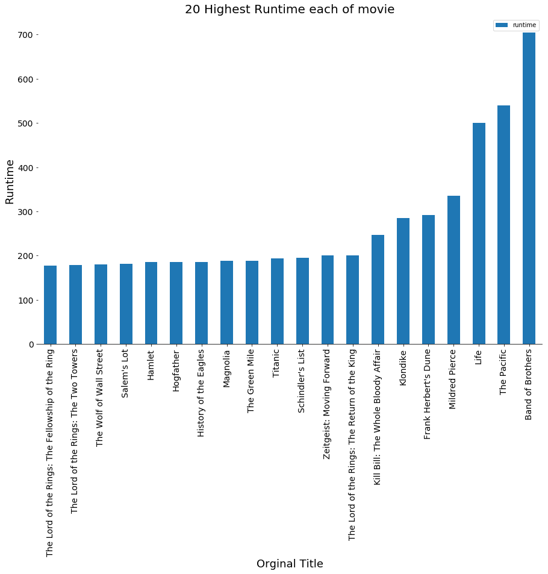

```python
# reating a bar chart for runtime and orginal title
bar_runtime= pd.DataFrame({'runtime': counts_runtime['runtime'].values},
                           #'profit': counts_revenue['profit'].values,
                           #'budget': counts_revenue['budget'].values},
                            index= counts_runtime['original_title'].values)
# presenting categorical data with rectangular bars with lengths
# proportional to the values that runtime represent
ax= bar_runtime.plot.bar(figsize= (15, 10), fontsize= 14, rot=90)

# adding a title to the Figure
ax.set_title('20 Highest Runtime each of movie', fontsize= 20)

# adding a label to the Axes's x-axis
ax.set_xlabel('Orginal Title', fontsize= 18)

# adding a label to the Axes's y-axis
ax.set_ylabel('Runtime', fontsize= 18)

# hiding the top line connecting the Axes's X-axis
# which has boundaried of the data area
ax.spines['top'].set_visible(False)
# hiding the right line connecting  the Axes's Y-axis
# which has boundaried of the data area
ax.spines['right'].set_visible(False)
# hiding the left line connecting the Axes's Y-axis
# which has boundaried of the data area
ax.spines['left'].set_visible(False);
```

### Research Question 2 (What is year has the muchest recording of movies?)

```python
# make group for each year and count the number of
# movies in each year
count_movie = df.groupby('release_year')['id'].count()
print(count_movie.tail(10))
```

```
release_year
2006     92
2007    135
2008    142
2009    192
2010    206
2011    219
2012    145
2013    128
2014    153
2015    165
Name: id, dtype: int64
```

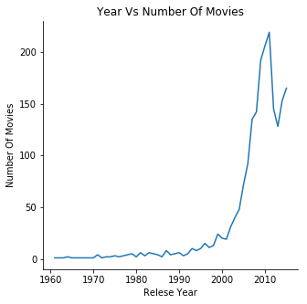

```python
# creating a graph chart for number of movies vs each year
fig,ax= plt.subplots(figsize=(5, 5));
ax.plot(count_movie.index, count_movie.values); # data.index : x , data.values : y

ax.set_title('Year Vs Number Of Movies')
ax.set_xlabel('Relese Year')
ax.set_ylabel('Number Of Movies');
ax.spines['top'].set_visible(False)
ax.spines['right'].set_visible(False)
```